# GitHub Packages

[Download Materials](https://github.com/DavidMartinConsulting/DM_Consulting/blob/gh-pages/GitHub_Packages.zip?raw=true)

# Purpose of this Document

The purpose of this document is to provide instructions on how to utilize packages for R that are available on GitHub, but are not currently easily accessible from repositories like CRAN.

# Getting Started

To get started we are going to need to install a few packages from the CRAN (more on this later). Today we are going to use the `githubinstall`, `remotes`, and `gapminder` packages. The first two are for downloading and installing packages from GitHub. The final package will be used to download the `gapminder` dataset for use with the various packages we download from GitHub.

```r
# Packages to install
  # install.packages("githubinstall")
  # install.packages("remotes")
  # install.packages("gapminder")
  # if necessary
    # install.packages("tidyverse)

# Loading up the tidyverse package
library(tidyverse)

# Saving the gapminder dataset as an object to
# use later on
gm <- gapminder::gapminder
```

# Typical Package Implementation

In general, when trying to add functionality to base R, you search for a package on the CRAN (the Comprehensive R Archive Network) and simply use the `install.packages` function to download and install the package and functionality. Packages on the CRAN have gone through a vetting process to ensure that they are safe and do what they say they will do. However, oftentimes you find a function or package that you would like to use, but it has not gone through the CRAN vetting process and is only available on sites like GitHub. There are also times when a package is available on the CRAN, but certain functionality that you want to utilize has not been vetted or added to the CRAN. Developers will often have development or beta versions of their packages that they will make available via GitHub before they go on the CRAN.

# Methods for Utilizing GitHub packages

## Using the `githubinstall` and `remotes` packages

Two of the most common options within R available for using packages that are located on GitHub are the `githubinstall` and `remotes` packages. Both of these packages retrieve packages available on GitHub and download them onto your local machine. However, they do it in slightly different ways. In the next two sections I am going to illustrate how to use each of the packages and will point out the pros and cons of each approach.

### The `githubinstall` package

The [githubinstall](https://cran.r-project.org/web/packages/githubinstall/vignettes/githubinstall.html) package is available from the CRAN to download using `install.packages`. The key advantages of using `githubinstall` is that it does not require you to know the exact name of the repository from GitHub and it allows you to do a fuzzy search for the name of the package. This means that you may not know exactly how to spell a package name, but the fuzzy search will enable you to get close enough to the right name. This is a useful feature, because sometimes package names in R can complicated and/or convoluted and it can also be difficult to remember repository names. However, it does make reproducibility difficult, in that extra manual input is needed from the user. Also, if two packages are similarly named and you do not know the name of the repo you were hoping to download from, you may end up downloading the wrong package, which could lead to some large issues.

The following vignettes will illustrate how to use `githubinstall` to find and download packages from GitHub.

The first step is to install `githubinstall`. Fortunately, `githubinstall` is available on the CRAN.

```r
# install.packages("githubinstall")
```

The next step is to try and find the GitHub package you were looking for. For instance, if I know I wanted to do something with a meta-analysis and found a package, but I forgot exactly where I saw the package. I am going to try and look for the package using the string “meta”

```r
# githubinstall and gh_install_packages do the same thing. githubinstall acts as
# an alias for the gh_install_packages function.
githubinstall::githubinstall("meta")
```

[figure not shown]

As you can see, two options were provided for me, both of them including packages called `meta`. Neither of the options provided were what I was looking for, so I entered a 0 to cancel out.

I am going to try something else. Within the `githubinstall` package, there is the `gh_search_packages` function that searches for keywords in the titles of GitHub repositories. This can help you to narrow down your search.

```r
githubinstall::gh_search_packages("metaanalysis")
```

```
##       username                            package_name
## 1 Bioconductor                                GeneMeta
## 2    JonasMoss                            metaanalysis
## 3      adsteen Lloyd.et.al.Cell.abundance.metaanalysis
##                                                                                 title
## 1                                        MetaAnalysis for High Throughput Experiments
## 2                                                                Work on metaanalysis
## 3 Code pertaining to a manuscript about a metaanalysis of cell quantification methods
```

`GeneMeta` is the package that I was looking for.

```r
githubinstall::githubinstall("GeneMeta")
```

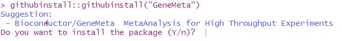

The `GeneMeta` package will now install like a normal package from CRAN. We now have access to the `GeneMeta` functions and can use them moving forward.

```r
ls(asNamespace("GeneMeta"))
```

```
##  [1] "CountPlot"      "dstar"          "f.Q"            "getdF"
##  [5] "getdF_matrix"   "IDRplot"        "mu.tau2"        "multExpFDR"
##  [9] "sigmad"         "tau2.DL"        "var.tau2"       "zScoreFDR"
## [13] "zScorePermuted" "zScores"
```

As you can see, all of the functions from `GeneMeta` are installed into our local machine.

#### Additional Useful Functions from `githubinstall()`

The `githubinstall` package also provides some useful functions for when you do not know exactly what you are looking for.

The `gh_suggest()` function suggests a possible repository based upon an incomplete repo name. So if you knew you were looking for something on Bayesian Statistics, but you did not remember the repo, you can use `gh_suggest()` to create a vector of possibilities.

```r
githubinstall::gh_suggest(repo_name = "Bayesian_Stat")
```

```
## [1] "lockEF/BayesianPGMM"      "rnorouzian/BayesianforL2"
## [3] "student-t/Bayesian"
```

```r
# This provides us with three different possibilities,
# that we could then use as input to the githubinstall function

# githubinstall::githubinstall(githubinstall::gh_suggest(repo_name = "Bayesian_Stat")[3])
```

```r
githubinstall::gh_list_packages(username = "student-t")
```

```
##    username  package_name
## 1 student-t       Anaquin
## 2 student-t      Bayesian
## 3 student-t CancerSomatic
## 4 student-t  CurveFitting
## 5 student-t  DecisionTree
## 6 student-t Normalization
## 7 student-t      RAnaquin
## 8 student-t      RFinance
##                                                      title
## 1            R-package for statistical analysis of sequins
## 2
## 3
## 4            Statistical algorithms for curve fitting in R
## 5
## 6 R package for normalization algorithms in bioinformatics
## 7            R-package for statistical analysis of sequins
## 8          R package for modelling in quantitative finance
```

```r
#We can also look for something in hadley wickhams
githubinstall::gh_list_packages(username = "hadley") %>% head(n = 20)
```

```
##    username package_name
## 1    hadley RcppDateTime
## 2    hadley           S3
## 3    hadley   assertthat
## 4    hadley    babynames
## 5    hadley        bench
## 6    hadley    bigrquery
## 7    hadley       bigvis
## 8    hadley     bookdown
## 9    hadley    classifly
## 10   hadley   clusterfly
## 11   hadley    colformat
## 12   hadley       dbplyr
## 13   hadley      decumar
## 14   hadley   densityvis
```

[output cut: 27 more lines]

```r
#You can also look in more than one users repo.
githubinstall::gh_list_packages(username = c("hadley", "yihui", "student-t")) %>% tail(n = 20)
```

```
##     username package_name
## 113    yihui    animation
## 114    yihui     crandalf
## 115    yihui      formatR
## 116    yihui          fun
## 117    yihui        highr
## 118    yihui        iBUGS
## 119    yihui        knitr
## 120    yihui         mime
## 121    yihui       printr
## 122    yihui     recharts
## 123    yihui          rlp
## 124    yihui        rmini
## 125    yihui    rnotebook
## 126    yihui         runr
```

[output cut: 27 more lines]

### `install_github` from `remotes`

The [`install_github`](https://www.rdocumentation.org/packages/devtools/versions/1.13.6/topics/install_github) function, from the `remotes` package (which itself is included in the `devtools` package) has an extra requirement above `githubinstall`, in that you need to know the name of the repository/repo. This is both a positive and a negative. It is positive because it ensures that you are getting the right package and not doing a best guess, as `github_install` does. However, this does decrease the amount of flexibility you have when downloading and installing packages from github and adds an extra burden to the user.

For this example, we are going to use the `ggtrace` package. The [ggtrace](https://rnabioco.github.io/ggtrace/) package allows for the highlighting of specific portions of a graph. This package is only available on github.

In order to use `install_github` you need to ensure that you have the `devtools` package, which contains the `remotes` package, installed and loaded.

```r
# install.packages("devtools")
# install.packages("remotes")
library(devtools)
#?remotes::install_github
```

The only option/argument that is required for the `install_github` function is the name of the repository that you are looking to download from.

```r
remotes::install_github(repo = "rnabioco/ggtrace")
```

If you have already installed the package, the install will be skipped, unless you add the `force = TRUE` option, which will reinstall a package.

I can now access the `ggtrace` package from the `rnabioco` repo.

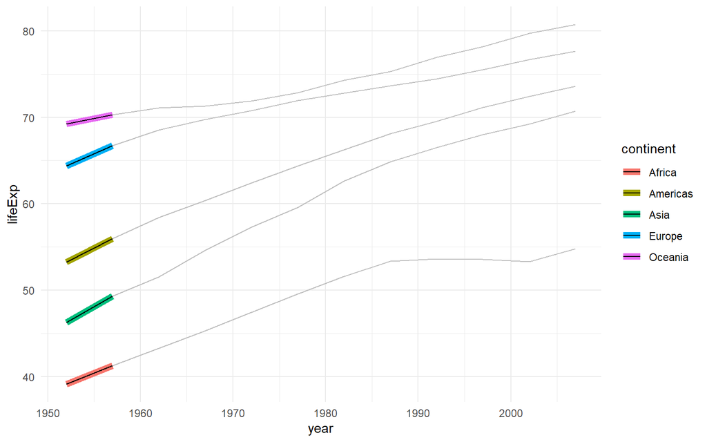

```r
gm %>% group_by(year, continent) %>%
  summarize(lifeExp = mean(lifeExp)) %>%
ggplot(aes(year, lifeExp, color = continent)) +
  theme_minimal() +
  ggtrace::geom_line_trace(
    trace_position    = year < 1962 & year > 1950,
    stroke            = 1,
    background_params = list(color = NA, fill = "grey75")
  )
```

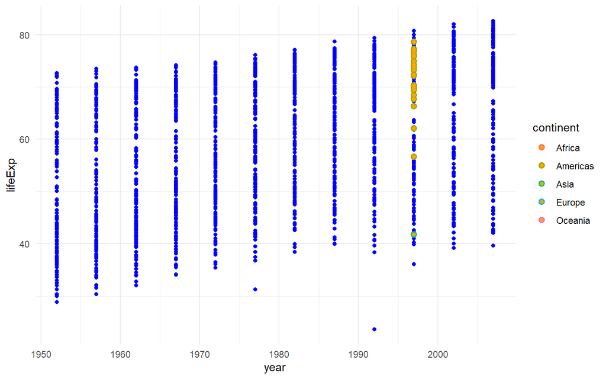

```r
gm %>%
ggplot(aes(year, lifeExp, color = continent)) +
  theme_minimal() +
  ggtrace::geom_point_trace(
    trace_position    = (continent == "Americas" | country == "Afghanistan") & year == 1997,
    fill              = "orange",
    background_params = list(color = NA, fill = "blue")
  )
```

#### Additional Useful Functions from the `remotes` package

The `remotes` package overall is quite useful for the downloading of packages from just about anywhere. It also has a useful helper function called `update_packages` that will ask if you want to update any installed packages, from the CRAN, GitHub, or any other location. You can either update all packages, or you can update specific packages using the `packages` option.

```r
#remotes::update_packages()
remotes::update_packages(packages = c("ggtrace", "dmetar"))
```

### Manually Downloading Packages

Another possible way to get packages from GitHub (and also other sources) is to manually download a zipped file version of the package. This can be done using another version of the `install_` family of functions from the `devtools` and `remotes` packages. Below, I have steps that you would take to find, download, and install a package to your local machine.

```r
# Use .libPaths() to find your local directory
.libPaths()

# Save your local directory as dir
dir <- .libPaths()[1]
```

Clone GitHub page as Zip file

[figure not shown]

Download zip file and unzip the file in your local directory (the `dir` object)

Use the install_local function from `devtools/remotes` to install the package

```r
# install_local("path/to/unzipped_pkg_zip_file")
install_local(paste0(dir, "/ggtech-master/ggtech-master"), force = TRUE)

# force = TRUE will overwrite an already installed version
```

## Recommendation

My final recommendation for the best way to download packages from GitHub would be to use the `install_github` function. In general, it is not too difficult to know the name of a repository and utilizing both the exact repo name and package name ensures that you are using the specific package you were hoping to use.

## Other Resources/Links

[`pacman`](https://github.com/trinker/pacman) [`devtools`](https://github.com/r-lib/devtools)